# Содержание

- 1-Обзор данных
- 2-Предобработка данных
  - 2.1-Обработка пропущенных значений
  - 2.2-Обработка явных дубликатов
  - 2.3-Обработка неявных дубликатов
- 3-Исследовательский анализ данных
  - 3.1-Статистический анализ
    - 3.1.1-Анализ таблицы train_job_satisfaction_rate
    - 3.1.2-Анализ таблицы train_quit
  - 3.2-Статистический анализ: вывод
  - 3.3-Корреляционный анализ признаков
    - 3.3.1-Анализ таблицы train_job_satisfaction_rate
    - 3.3.2-Анализ таблицы train_quit
- 4-Решение задачи регрессии
  - 4.1-Создание пайплайна
  - 4.2-Обучение моделей
  - 4.3-Анализ важности признаков
- 5-Решение задачи классификации
  - 5.1-Подготовка данных
  - 5.2-Создание пайплайна
  - 5.3-Обучение моделей
- 6-Общий вывод

# HR-аналитика

**Цель исследования** — оптимизировать управление персоналом, предсказав возможный отток сотрудников.

**Для этого** построим две прогнозные модели:

1. Первая модель предскажет уровень удовлетворённости сотрудника на основе данных заказчика;
2. Вторая модель спрогнозирует вероятное увольнение сотрудника из компании.

**Описание данных**

1. Для предсказания уровня удовлетворённости сотрудника заказчик предоставил данные в CSV-файлах:
- `train_job_satisfaction_rate.csv` — тренировочная выборка;
- `test_features.csv` — входные признаки тестовой выборки;
- `test_target_job_satisfaction_rate.csv` — целевой признак тестовой выборки

Данные содержат следующие признаки:

- `id` — уникальный идентификатор сотрудника;
- `dept` — отдел, в котором работает сотрудник;
- `level` — уровень занимаемой должности;
- `workload` — уровень загруженности сотрудника;
- `employment_years` — длительность работы в компании (в годах);
- `last_year_promo` — показывает, было ли повышение за последний год;
- `last_year_violations` — показывает, нарушал ли сотрудник трудовой договор за последний год;
- `supervisor_evaluation` — оценка качества работы сотрудника, которую дал руководитель;
- `salary` — ежемесячная зарплата сотрудников;
- `job_satisfaction_rate` — уровень удовлетворённости сотрудника работой в компании (целевой признак)
2. Для предсказания возможного увольнения сотрудника из компании используем те же входные признаки. Однако целевым признаком будет `quit` — увольнение сотрудника:
- `train_quit.csv` — тренировочная выборка;
- `test_features.csv` — тестовая выборка (с теми же входными признаками, что и в первой задаче);
- `test_target_quit.csv` — целевой признак тестовой выборки.

**Ход исследования**

Исследование пройдёт в 4 этапа:

1. Обзор данных.

Ознакомимся со структурой данных в датафреймах, проверим их содержание на соответствие признаковому описанию.

2. Предобработка данных.

Проверим данные на наличие проблем, таких как пропуски, явные и неявные дубликаты, некорректные типы данных в столбцах.

3. Исследовательский анализ данных.

Проведём статистический анализ данных и проверим, как распределены значения в каждом столбце, присутствуют ли аномалии или выбросы. Изучим корреляцию целевых и входных признаков датафрейма, при необходимости исключим мультиколлинеарность.

4. Обучение прогнозных моделей.

Создадим пайплайны и обучим модели. Оценим точность прогнозов с помощью ключевых метрик.

Результаты моделирования позволят избежать финансовых потерь в результате внезапных увольнений сотрудников, улучшить стратегию удержания персонала в компании.

## Обзор данных

```python
# отключаем предупреждение от tqdm о IProgress:
# оно не влияет на работу кода, и мы сознательно не используем прогресс-бары через виджеты в Jupyter
# устанавливаем рендерер plotly на 'notebook_connected'
# чтобы графики отображались интерактивно в Jupyter через HTML/JS
# а не через Jupyter widgets (которые могут конфликтовать с ipywidgets)
import warnings
from tqdm import TqdmWarning
import plotly.io as pio

warnings.filterwarnings("ignore", category=TqdmWarning)
pio.renderers.default = 'notebook_connected'
```

Импортируем все необходимые библиотеки и константы:

```python
# импортируем библиотеки для анализа данных и визуализации
import pandas as pd
import matplotlib.pyplot as plt
import seaborn as sns
import plotly.express as px
import plotly.graph_objects as go
import numpy as np
import phik
import shap

# импортируем библиотеки для подготовки данных и обучения моделей
# обозначим константы
RANDOM_STATE = 42
TEST_SIZE = 0.25

# импортируем классы для работы с пайплайном
from sklearn.pipeline import Pipeline
from sklearn.compose import ColumnTransformer
from sklearn.impute import SimpleImputer

#импортируем классы для кодирования и масштабирования данных
from sklearn.preprocessing import (
                                  OneHotEncoder,
                                  OrdinalEncoder,
                                  RobustScaler,
                                  StandardScaler,
                                  MinMaxScaler,
                                  LabelEncoder,
                                  FunctionTransformer
                                )

# импортируем классы для деления данных на выборки и перебора гиперпараметров
from sklearn.model_selection import RandomizedSearchCV

# импортируем модели
from sklearn.linear_model import (
                            LinearRegression,
                            LogisticRegression
                        )
from sklearn.tree import (
                            DecisionTreeRegressor,
                            DecisionTreeClassifier
                        )
from sklearn.neighbors import KNeighborsClassifier
from sklearn.svm import SVC

# импортируем метрики для оценки
from sklearn.metrics import (
                            make_scorer,
                            roc_auc_score
                        )
```

Считаем CSV-файлы с таблицами и сохраним их в датафреймы pandas:

```python
# считаем csv-файлы с помощью pd.read_csv()
# датафреймы для первой задачи
train_job_satisfaction_rate = pd.read_csv('https://code.s3.yandex.net/datasets/train_job_satisfaction_rate.csv')
test_features = pd.read_csv('https://code.s3.yandex.net/datasets/test_features.csv')
test_target_job_satisfaction_rate = pd.read_csv('https://code.s3.yandex.net/datasets/test_target_job_satisfaction_rate.csv')

# датафреймы для второй задачи
train_quit = pd.read_csv('https://code.s3.yandex.net/datasets/train_quit.csv')
test_target_quit = pd.read_csv('https://code.s3.yandex.net/datasets/test_target_quit.csv')
```

Ознакомимся с первыми 20 строками датафреймов:

```python
# выведем первые 20 строк таблицы train_job_satisfaction_rate
train_job_satisfaction_rate.head(20)
```

|  | id | dept | level | workload | employment_years | last_year_promo | last_year_violations | supervisor_evaluation | salary | job_satisfaction_rate |
| --- | --- | --- | --- | --- | --- | --- | --- | --- | --- | --- |
| 0 | 155278 | sales | junior | medium | 2 | no | no | 1 | 24000 | 0.58 |
| 1 | 653870 | hr | junior | high | 2 | no | no | 5 | 38400 | 0.76 |
| 2 | 184592 | sales | junior | low | 1 | no | no | 2 | 12000 | 0.11 |
| 3 | 171431 | technology | junior | low | 4 | no | no | 2 | 18000 | 0.37 |
| 4 | 693419 | hr | junior | medium | 1 | no | no | 3 | 22800 | 0.20 |
| 5 | 405448 | hr | middle | low | 7 | no | no | 4 | 30000 | 0.78 |
| 6 | 857135 | sales | sinior | medium | 9 | no | no | 3 | 56400 | 0.56 |
| 7 | 400657 | purchasing | middle | high | 9 | no | no | 3 | 52800 | 0.44 |
| 8 | 198846 | hr | junior | low | 1 | no | no | 2 | 13200 | 0.14 |
| 9 | 149797 | technology | middle | high | 6 | no | no | 3 | 54000 | 0.47 |
| 10 | 964158 | purchasing | junior | low | 2 | no | no | 4 | 13200 | 0.74 |
| 11 | 784541 | sales | middle | low | 3 | no | no | 4 | 19200 | 0.42 |
| 12 | 569960 | sales | middle | medium | 3 | no | no | 3 | 38400 | 0.32 |
| 13 | 381081 | marketing | junior | high | 2 | no | no | 2 | 40800 | 0.57 |
| 14 | 581188 | marketing | middle | medium | 4 | no | no | 2 | 34800 | 0.16 |
| 15 | 798010 | technology | junior | medium | 3 | no | no | 4 | 27600 | 0.69 |
| 16 | 861046 | hr | junior | medium | 1 | no | no | 3 | 26400 | 0.33 |
| 17 | 955615 | purchasing | junior | high | 2 | no | no | 5 | 33600 | 0.64 |
| 18 | 848242 | sales | middle | high | 2 | yes | no | 1 | 50400 | 0.39 |
| 19 | 732462 | sales | junior | low | 2 | no | yes | 4 | 15600 | 0.74 |

```python
# выведем первые 20 строк таблицы test_features
test_features.head(20)
```

|  | id | dept | level | workload | employment_years | last_year_promo | last_year_violations | supervisor_evaluation | salary |
| --- | --- | --- | --- | --- | --- | --- | --- | --- | --- |
| 0 | 485046 | marketing | junior | medium | 2 | no | no | 5 | 28800 |
| 1 | 686555 | hr | junior | medium | 1 | no | no | 4 | 30000 |
| 2 | 467458 | sales | middle | low | 5 | no | no | 4 | 19200 |
| 3 | 418655 | sales | middle | low | 6 | no | no | 4 | 19200 |
| 4 | 789145 | hr | middle | medium | 5 | no | no | 5 | 40800 |
| 5 | 429973 | purchasing | middle | medium | 6 | no | no | 3 | 42000 |
| 6 | 850699 | technology | junior | medium | 3 | no | no | 3 | 26400 |
| 7 | 500791 | sales | middle | high | 9 | no | no | 4 | 49200 |
| 8 | 767867 | marketing | middle | high | 3 | no | yes | 4 | 62400 |
| 9 | 937235 | sales | junior | medium | 1 | no | yes | 3 | 26400 |
| 10 | 354261 | technology | junior | low | 3 | no | no | 3 | 14400 |
| 11 | 473072 | hr | middle | medium | 1 | no | no | 4 | 36000 |
| 12 | 984128 | sales | middle | medium | 5 | no | no | 3 | 33600 |
| 13 | 252146 | marketing | middle | low | 7 | no | yes | 1 | 19200 |
| 14 | 838149 | technology | middle | medium | 4 | yes | no | 2 | 44400 |
| 15 | 590867 | marketing | junior |  | 4 | no | no | 4 | 28800 |
| 16 | 849959 | technology | middle | low | 2 | no | no | 4 | 27600 |
| 17 | 780847 | sales | junior | low | 1 | no | no | 2 | 14400 |
| 18 | 335909 | hr | junior | low | 1 | no | no | 1 | 12000 |
| 19 | 179164 | technology | sinior | medium | 8 | no | no | 4 | 64800 |

```python
# выведем первые 20 строк таблицы test_target_job_satisfaction_rate
test_target_job_satisfaction_rate.head(20)
```

|  | id | job_satisfaction_rate |
| --- | --- | --- |
| 0 | 130604 | 0.74 |
| 1 | 825977 | 0.75 |
| 2 | 418490 | 0.60 |
| 3 | 555320 | 0.72 |
| 4 | 826430 | 0.08 |
| 5 | 817219 | 0.76 |
| 6 | 269033 | 0.64 |
| 7 | 962356 | 0.38 |
| 8 | 649052 | 0.14 |
| 9 | 532834 | 0.59 |
| 10 | 436938 | 0.91 |
| 11 | 759748 | 0.78 |
| 12 | 462750 | 0.70 |
| 13 | 120724 | 0.79 |
| 14 | 161234 | 0.74 |
| 15 | 217807 | 0.34 |
| 16 | 311719 | 0.81 |
| 17 | 377223 | 0.23 |
| 18 | 700796 | 0.23 |
| 19 | 304609 | 0.40 |

```python
# выведем первые 20 строк таблицы train_quit
train_quit.head(20)
```

|  | id | dept | level | workload | employment_years | last_year_promo | last_year_violations | supervisor_evaluation | salary | quit |
| --- | --- | --- | --- | --- | --- | --- | --- | --- | --- | --- |
| 0 | 723290 | sales | middle | high | 2 | no | no | 4 | 54000 | no |
| 1 | 814010 | sales | junior | medium | 2 | no | no | 4 | 27600 | no |
| 2 | 155091 | purchasing | middle | medium | 5 | no | no | 1 | 37200 | no |
| 3 | 257132 | sales | junior | medium | 2 | no | yes | 3 | 24000 | yes |
| 4 | 910140 | marketing | junior | medium | 2 | no | no | 5 | 25200 | no |
| 5 | 699916 | sales | junior | low | 1 | no | yes | 3 | 18000 | yes |
| 6 | 417070 | technology | middle | medium | 8 | no | no | 2 | 44400 | no |
| 7 | 165489 | sales | middle | low | 4 | no | no | 5 | 19200 | no |
| 8 | 996399 | marketing | middle | low | 7 | no | no | 4 | 25200 | no |
| 9 | 613206 | technology | middle | medium | 2 | no | no | 3 | 45600 | yes |
| 10 | 832644 | sales | middle | high | 3 | no | no | 4 | 57600 | no |
| 11 | 260997 | sales | middle | medium | 5 | no | no | 3 | 33600 | no |
| 12 | 114153 | marketing | junior | low | 3 | no | no | 4 | 16800 | no |
| 13 | 672533 | marketing | middle | medium | 3 | yes | yes | 1 | 44400 | no |
| 14 | 453936 | purchasing | junior | medium | 2 | no | no | 4 | 22800 | no |
| 15 | 741016 | technology | junior | medium | 1 | no | no | 4 | 26400 | no |
| 16 | 113657 | technology | sinior | high | 5 | yes | no | 3 | 82800 | no |
| 17 | 458930 | sales | middle | low | 5 | no | no | 4 | 24000 | no |
| 18 | 999835 | sales | junior | low | 5 | no | no | 4 | 18000 | no |
| 19 | 120366 | hr | middle | low | 9 | no | no | 4 | 25200 | no |

```python
# выведем первые 20 строк таблицы test_target_quit
test_target_quit.head(20)
```

|  | id | quit |
| --- | --- | --- |
| 0 | 999029 | yes |
| 1 | 372846 | no |
| 2 | 726767 | no |
| 3 | 490105 | no |
| 4 | 416898 | yes |
| 5 | 223063 | no |
| 6 | 810370 | no |
| 7 | 998900 | no |
| 8 | 578329 | no |
| 9 | 648850 | no |
| 10 | 705199 | no |
| 11 | 867119 | no |
| 12 | 653711 | no |
| 13 | 501821 | no |
| 14 | 509518 | no |
| 15 | 605830 | no |
| 16 | 709750 | yes |
| 17 | 807221 | no |
| 18 | 644517 | no |
| 19 | 484268 | no |

Предварительно обнаружили проблему в таблице `test_features` — пробел в пятнадцатой строке в столбце `workload` у сотрудника с `id` **590867**.

Изучим общую информацию о таблицах:

```python
# выведем общую информацию о таблице
train_job_satisfaction_rate.info()
```

```
<class 'pandas.core.frame.DataFrame'>
RangeIndex: 4000 entries, 0 to 3999
Data columns (total 10 columns):
 #   Column                 Non-Null Count  Dtype
---  ------                 --------------  -----
 0   id                     4000 non-null   int64
 1   dept                   3994 non-null   object
 2   level                  3996 non-null   object
 3   workload               4000 non-null   object
 4   employment_years       4000 non-null   int64
 5   last_year_promo        4000 non-null   object
 6   last_year_violations   4000 non-null   object
 7   supervisor_evaluation  4000 non-null   int64
 8   salary                 4000 non-null   int64
 9   job_satisfaction_rate  4000 non-null   float64
dtypes: float64(1), int64(4), object(5)
memory usage: 312.6+ KB
```

В таблице `train_job_satisfaction_rate`:

- **10** столбцов и **4 000** строк.
- Пропущенные значения в столбцах `dept` и `level`.
- Корректно обозначены типы данных во всех столбцах.

```python
# выведем общую информацию о таблице
test_features.info()
```

```
<class 'pandas.core.frame.DataFrame'>
RangeIndex: 2000 entries, 0 to 1999
Data columns (total 9 columns):
 #   Column                 Non-Null Count  Dtype
---  ------                 --------------  -----
 0   id                     2000 non-null   int64
 1   dept                   1998 non-null   object
 2   level                  1999 non-null   object
 3   workload               2000 non-null   object
 4   employment_years       2000 non-null   int64
 5   last_year_promo        2000 non-null   object
 6   last_year_violations   2000 non-null   object
 7   supervisor_evaluation  2000 non-null   int64
 8   salary                 2000 non-null   int64
dtypes: int64(4), object(5)
memory usage: 140.8+ KB
```

В датафрейме `test_features`:

- **9** столбцов и **2 000** строк.
- **2** пропуска в столбце `dept` и **1** — в `level`.
- Верно обозначены типы данных.

```python
# выведем общую информацию о таблице
test_target_job_satisfaction_rate.info()
```

```
<class 'pandas.core.frame.DataFrame'>
RangeIndex: 2000 entries, 0 to 1999
Data columns (total 2 columns):
 #   Column                 Non-Null Count  Dtype
---  ------                 --------------  -----
 0   id                     2000 non-null   int64
 1   job_satisfaction_rate  2000 non-null   float64
dtypes: float64(1), int64(1)
memory usage: 31.4 KB
```

В таблице с целевой переменной `test_target_job_satisfaction_rate`:

- **2** столбца и **2 000** строк.
- Отсутствуют пропуски, правильно обозначены типы данных.

```python
# выведем общую информацию о таблице
train_quit.info()
```

```
<class 'pandas.core.frame.DataFrame'>
RangeIndex: 4000 entries, 0 to 3999
Data columns (total 10 columns):
 #   Column                 Non-Null Count  Dtype
---  ------                 --------------  -----
 0   id                     4000 non-null   int64
 1   dept                   4000 non-null   object
 2   level                  4000 non-null   object
 3   workload               4000 non-null   object
 4   employment_years       4000 non-null   int64
 5   last_year_promo        4000 non-null   object
 6   last_year_violations   4000 non-null   object
 7   supervisor_evaluation  4000 non-null   int64
 8   salary                 4000 non-null   int64
 9   quit                   4000 non-null   object
dtypes: int64(4), object(6)
memory usage: 312.6+ KB
```

В выборке `train_quit`:

- **10** столбцов и **4 000** строк.
- Нет пропусков.
- Корректный формат данных.

```python
# выведем общую информацию о таблице
test_target_quit.info()
```

```
<class 'pandas.core.frame.DataFrame'>
RangeIndex: 2000 entries, 0 to 1999
Data columns (total 2 columns):
 #   Column  Non-Null Count  Dtype
---  ------  --------------  -----
 0   id      2000 non-null   int64
 1   quit    2000 non-null   object
dtypes: int64(1), object(1)
memory usage: 31.4+ KB
```

В таблице `test_target_quit`:

- **2** столбца и **2 000** строк;
- Отсутствуют пропуски, верно обозначен формат данных.

**Выводы**:

Предварительно обнаружили в данных следующие проблемы:

- Пропуски в таблицах `train_job_satisfaction_rate` и `test_features` в столбцах `dept` и `level`;
- Пробел в пятнадцатой строке в таблице `test_features`.

Во всех датафреймах корректно обозначен тип данных.

Проведём более тщательный поиск возможных ошибок и мусора в данных на этапе предобработки.

## Предобработка данных

- Проведём предобработку данных в обеих тренировочных выборках. Данные в тестовых выборках обработаем в пайплайне, на этапе подготовки к обучению модели.

### Обработка пропущенных значений

- Заполним пропуски в столбцах `dept` и `level` пайплайне.

Определим признаки для заполнения пропусков:

```python
# сохраним в переменную столбцы с пропусками
fill_categorical_features = ['dept', 'level']
```

```python
# заполним пропуски модой
fill_pass_categorial = Pipeline([
    ('simple_imputer_cat', SimpleImputer(strategy='most_frequent'))
])

pass_processing = ColumnTransformer(
    transformers=[
        ('fill_pass_categorial', fill_pass_categorial, fill_categorical_features)
    ],
    remainder='passthrough',
    verbose_feature_names_out=False
).set_output(transform="pandas")
```

Заполнили пропуски в столбцах модой, а не строкой `"неизвестно"`, так как количество пропусков незначительно и использование моды не сильно искажает реальную картину в данных.

Мода позволяет сохранить распределение текущих категорий, а не добавляет новую, как строка. Это поможет избежать лишнего шума при обучении моделей.

### Обработка явных дубликатов

Проверим 2 таблицы на наличие явных дублей:

```python
# для проверки на дубли спользуем методы duplicated() и sum()
train_job_satisfaction_rate.duplicated().sum()
```

```
0
```

```python
# для проверки на дубли спользуем методы duplicated() и sum()
train_quit.duplicated().sum()
```

```
0
```

Явные дубликаты отсутствуют в таблицах.

### Обработка неявных дубликатов

Проверим столбцы с категориальными переменными на наличие неявных дублей.

- Выведем перечень уникальных значений столбцов таблицы `train_job_satisfaction_rate`: `dept`, `level`, `workload`, `last_year_promo`, `last_year_violations`.

```python
# выведем перечень уникальных имён столбца
train_job_satisfaction_rate['dept'].unique()
```

```
array(['sales', 'hr', 'technology', 'purchasing', 'marketing', nan],
      dtype=object)
```

```python
# выведем перечень уникальных имён столбца
train_job_satisfaction_rate['level'].unique()
```

```
array(['junior', 'middle', 'sinior', nan], dtype=object)
```

В колонке `level` встречается ошибка: `sinior` вместо `senior`. Исправим орфографическую ошибку в пайплайне:

```python
# напишем функцию для обработки значения
def fix_typo_level(df):
    df = df.copy()
    df['level'] = df['level'].replace('sinior', 'senior')
    return df

typo_corrector = FunctionTransformer(fix_typo_level)
```

```python
# выведем перечень уникальных имён столбца
train_job_satisfaction_rate['workload'].unique()
```

```
array(['medium', 'high', 'low'], dtype=object)
```

```python
# выведем перечень уникальных имён столбца
train_job_satisfaction_rate['last_year_promo'].unique()
```

```
array(['no', 'yes'], dtype=object)
```

```python
# выведем перечень уникальных имён столбца
train_job_satisfaction_rate['last_year_violations'].unique()
```

```
array(['no', 'yes'], dtype=object)
```

Во всех категориальных столбцах таблицы отсутствуют неявные дубликаты.

- Выведем перечень уникальных значений столбцов таблицы `train_quit`:

```python
# выведем перечень уникальных значений столбца
train_quit['dept'].unique()
```

```
array(['sales', 'purchasing', 'marketing', 'technology', 'hr'],
      dtype=object)
```

```python
# выведем перечень уникальных значений столбца
train_quit['level'].unique()
```

```
array(['middle', 'junior', 'sinior'], dtype=object)
```

```python
# выведем перечень уникальных значений столбца
train_quit['workload'].unique()
```

```
array(['high', 'medium', 'low'], dtype=object)
```

```python
# выведем перечень уникальных значений столбца
train_quit['last_year_promo'].unique()
```

```
array(['no', 'yes'], dtype=object)
```

```python
# выведем перечень уникальных значений столбца
train_quit['last_year_violations'].unique()
```

```
array(['no', 'yes'], dtype=object)
```

```python
# выведем перечень уникальных значений столбца
train_quit['quit'].unique()
```

```
array(['no', 'yes'], dtype=object)
```

В столбцах таблицы отсутствуют неявные дубли.

**Выводы**:

- Заполнили пропущенные значения в категориальных столбцах `dept` и `level` в таблице `train_job_satisfaction_rate`. В качестве способа заполнения выбрали моду;
- Исправили ошибку в колонке `level` в пайплайне: заменили `sinior` на `senior`.

## Исследовательский анализ данных

### Статистический анализ

Проанализируем распределение значений в столбцах с категориальными и числовыми переменными в тренировочных выборках `train_job_satisfaction_rate` и `train_quit` с помощью визуализации:

- Используем иерархическую круговую и столбчатую диаграмму для категориальных переменных;
- Построим гистограмму и диаграмму размаха для числовых переменных.

А также:

- Выявим характеристики сотрудника с высоким и низким уровнем удовлетворённости;
- Составим портрет уволившегося сотрудника и сотрудника, который продолжает работу в компании;
- Исследуем взаимосвязь между уровнем удовлетворённости сотрудника и фактом его увольнения.
- При необходимости, очистим столбцы от аномалий и выбросов.

Уделим особое внимание *тренировочным данным*, но также посмотрим на *тестовые выборки*: `test_features`, `test_target_job_satisfaction`, `test_target_quit`. Проанализируем сходство данных для обучения с данными для тестирования.

#### Анализ таблицы train_job_satisfaction_rate

Используем иерархическую круговую диаграмму Sunburst для всех категориальных столбцов датафрейма, чтобы проанализировать взаимосвязи между элементами на разных уровнях. Например, как уровень удовлетворённости распределяется по отделам, позициям, рабочей нагрузке и т.д.:

```python
# напишем функцию для создания sunburst
def sunburst_creation(data, columns, target):
# cруппируем данные по категориям и для каждой посчитаем медиану удовлетворённости
    agg = data.groupby(columns)[target].median().reset_index()

# построим диаграмму
    fig = px.sunburst(
        agg,
# иерархия: отдел - грейд - нагрузка - наличие повышения - нарушение трудового договора
        path=columns,
        values=target,
        color=target,
        color_continuous_scale='RdYlGn',
# возьмём реальный диапазон агрегированных данных
        range_color=[agg[target].min(), agg[target].max()],
        title='Удовлетворённость сотрудников по категориям',
        width=700,
        height=700
        )
    fig.show()

# вызовем функцию и оценим результат
sunburst_creation(train_job_satisfaction_rate, ['dept', 'level', 'workload', 'last_year_promo', 'last_year_violations'], 'job_satisfaction_rate')
```

[interactive chart not shown]

- Самый высокий уровень удовлетворённости сотрудников наблюдается в отделах `sales` и `hr` с медианой — **0.61** и **0.60**. Самый низкий уровень в отделе `marketing` — **0.55**.

Грейд сотрудников с самым высоким уровнем удовлетворённости в отделах:

- `Управления персоналом` — `middle` (**0.65**) и `senior`(**0.59**);
- `Продаж` — `senior` (**0.64**) и `middle` (**0.63**);
- `Закупок` — `senior` (**0.64**) и `middle` (**0.59**);
- `Информационных технологий` — `senior` (**0.60**) и `middle` (**0.55**);
- `Маркетинга` — `senior` (**0.57**) и `middle` (**0.56**).

Самый высокий уровень удовлетворённости с учётом всех категорий можно заметить у сотрудников:

- В отделе **продаж** на уровне **senior**, c **низким** уровнем нагрузки, **с повышением** за последний год и **отсутствием нарушений** трудового договора за последний год — **0.97**;
- В отделе **закупок** на уровне **senior**, cо **средним** уровнем нагрузки, **с повышением** за последний год и **отсутствием нарушений** трудового договора за последний год — **0.9**;
- В отделе **hr** на уровне **middle**, c **низким** уровнем нагрузки, **с повышением** за последний год и **отсутствием нарушений** трудового договора за последний год — **0.9**.

Наоборот, самый низкий уровень удовлетворённости с учётом всех категорий виден у сотрудников:

- В отделе **hr** на уровне **junior**, c **высоким** уровнем нагрузки, **без повышения** за последний год и с **наличием нарушений** трудового договора за последний год — **0.09**.
- В отделе **hr** на уровне **senior**, cо **средним** уровнем нагрузки, **без повышения** за последний год и с **наличием нарушений** трудового договора за последний год — **0.09**.
- В отделе **закупок** на уровне **senior**, c **высоким** уровнем нагрузки, **с повышением** за последний год и **наличием нарушений** трудового договора за последний год — **0.11**.

Построим столбчатые диаграммы для категориальных столбцов таблицы, оценим количество значений в каждой категории:

```python
# напишем функцию для построения столбчатых диаграмм в одной сетке
def barplots(data):
    # отберём категориальные столбцы датафрейма
    cat_cols_bar = data.select_dtypes(include=['object']).columns

    # создадим фигуру
    fig = go.Figure()

    # добавим по одному графику на каждый категориальный столбец
    for i, col in enumerate(cat_cols_bar):
        counts = data[col].value_counts()
        fig.add_trace(go.Bar(
            x=counts.index,
            y=counts.values,
            name=col,
            visible=(i==0),
            text=counts.values,
            textposition='outside',
            cliponaxis=False
        ))
    # создадим шаги для переключения между графиками
    steps = []
    for i, col in enumerate(cat_cols_bar):
        step = dict(
            method='update',
            args=[
                {'visible': [j == i for j in range(len(cat_cols_bar))]},
                {'title': {'text':f'Распределение {col}'}}
            ],
            label=col
        )
        steps.append(step)
    sliders = [dict(
        active=0,
        currentvalue={"prefix":'График: '},
        pad={"t":50},
        steps=steps
    )]

    fig.update_layout(
        sliders=sliders,
        title={'text':f'Распределение {cat_cols_bar[0]}'},
        height=500,
        width=900,
        yaxis_title='Количество сотрудников'
    )
    # выведем графики
    return fig.show()

# вызовем функцию
barplots(train_job_satisfaction_rate)
```

[interactive chart not shown]

Согласно распределению в столбце `dept`:

- Самый многочисленный отдел — `sales` c количеством сотрудников **1512**. Самый маленький отдел — `hr`, в нём всего **456** сотрудников.
- Такое распределение можно объяснить тем, что отдел продаж приносит прямую прибыль и, как правильно, в нём более ярко выражена текучка кадров. Например, считается, что Менеджеры по продажам склонны к быстрому выгоранию и смене места работы. Другим компаниям проще переманить таких сотрудников улучшением финансовых условий. В `hr`-отделе сотрудники работают более продолжительное время, они реже совершают карьерные переходы в силу специфики профессии.

В столбце `level`:

- В датафрейме представлено больше `младших специалистов` (**1894**), чем `специалистов среднего уровня` (**1744**). Меньше всего сотрудников уровня `senior` (**358**).
- Такое распределение соответствует действительности, так как не каждый сотрудник имеет желание или достаточно навыков и компетенций для вертикального роста.

В столбце `workload`:

- У большинства сотрудников средний уровень нагрузки — **2066**.
- Меньше всего сотрудников с высокой нагрузкой — **734**.

В столбце `last_year_promo`:

- Из **4000** сотрудников за последний год повышение получили только **120** человек, остальные **3880** сотрудников остались на прежних должностях.

В столбце `last_year_violations`:

- За последний год **559** сотрудников из **4000** нарушали трудовой договор.

Проанализируем распределение в столбце с количественными переменными `employment_years`.

Построим гистограмму и диаграмму размаха, чтобы оценить форму распределения и проверить данные на наличие выбросов и аномалий:

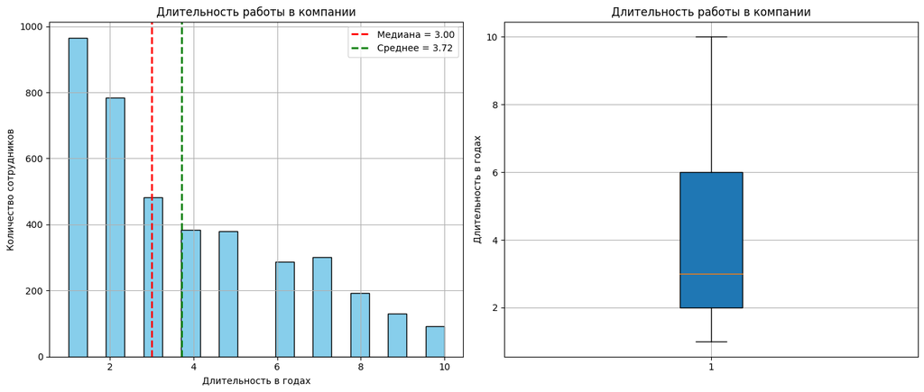

```python
def hist_boxplot_creation(data, column, bins, title, ylabel, xlabel):
    # создадим сетку графиков
    fig, axes = plt.subplots(1, 2, figsize=(14, 6))

    # сохраним датафрейм с нужным столбцом в переменную
    # рассчитаем медиану и среднее
    data = data[column]
    data_median = data.median()
    data_mean = data.mean()

    # построим гистограмму
    axes[0].hist(data, bins=bins, color='skyblue', edgecolor='black')
    axes[0].set_title(title)
    axes[0].set_ylabel(ylabel)
    axes[0].set_xlabel(xlabel)
    axes[0].grid(True)

    # добавим медиану и среднее на гистограмму
    axes[0].axvline(
        data_median,
        color='red',
        linestyle='dashed',
        linewidth=2,
        label=f'Медиана = {data_median:.2f}'
    )
    axes[0].axvline(
        data_mean,
        color='green',
        linestyle='dashed',
        linewidth=2,
        label=f'Среднее = {data_mean:.2f}'
    )

    # отобразим среднее и медиану на графике
    axes[0].legend()

    # построим диаграмму размаха
    axes[1].boxplot(data, patch_artist=True)
    axes[1].set_title(title)
    axes[1].set_ylabel(xlabel)
    axes[1].grid(True)

    # отобразим графики
    plt.tight_layout()
    return plt.show()

# вызовем функцию
hist_boxplot_creation(train_job_satisfaction_rate, 'employment_years', 20, 'Длительность работы в компании', 'Количество сотрудников', 'Длительность в годах')
```

- Значения распределены с асимметрией вправо, среднее арифметическое (**3.72**) незначительно больше медианы (**3**).
- На гистограмме отсутствуют "хвосты" или отдельные крупные значения.
- Диаграмма размаха показывает отсутствие выбросов в столбце.

Посмотрим, как распределены значения в столбце `supervisor_evaluation`:

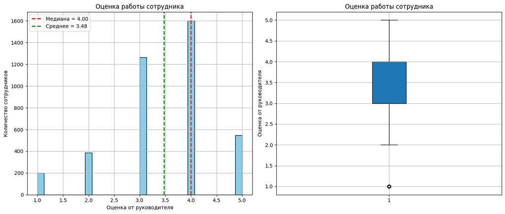

```python
# вызовем функцию для построения гистограммы и диаграммы размаха
hist_boxplot_creation(train_job_satisfaction_rate, 'supervisor_evaluation', 30, 'Оценка работы сотрудника', 'Количество сотрудников', 'Оценка от руководителя')
```

- Распределение асимметрично влево, медианное значение (**4**) выше среднего (**3.48**).
- Диаграмма размаха показывает выброс у отметки **1**.

Проверим контекст, выведем дополнительную информацию о сотрудниках с оценкой работы **1**:

```python
# выведем информацию о сотрудниках с помощью query()
train_job_satisfaction_rate.query('supervisor_evaluation == 1').head(10)
```

|  | id | dept | level | workload | employment_years | last_year_promo | last_year_violations | supervisor_evaluation | salary | job_satisfaction_rate |
| --- | --- | --- | --- | --- | --- | --- | --- | --- | --- | --- |
| 0 | 155278 | sales | junior | medium | 2 | no | no | 1 | 24000 | 0.58 |
| 18 | 848242 | sales | middle | high | 2 | yes | no | 1 | 50400 | 0.39 |
| 32 | 176144 | hr | sinior | high | 3 | no | no | 1 | 72000 | 0.22 |
| 45 | 538347 | technology | sinior | high | 3 | no | no | 1 | 84000 | 0.21 |
| 53 | 460328 | technology | junior | high | 1 | no | no | 1 | 37200 | 0.10 |
| 64 | 188350 | marketing | middle | high | 6 | no | yes | 1 | 60000 | 0.31 |
| 67 | 990103 | purchasing | middle | medium | 2 | no | no | 1 | 42000 | 0.33 |
| 87 | 702721 | sales | middle | medium | 6 | no | yes | 1 | 31200 | 0.15 |
| 91 | 641867 | technology | junior | high | 1 | no | no | 1 | 44400 | 0.36 |
| 109 | 303318 | marketing | junior | high | 5 | no | no | 1 | 33600 | 0.37 |

- Данные о сотрудниках выглядят реалистично. Не будем признавать оценку **1** выбросом, так как руководитель действительно может быть недоволен работой сотрудника.

Проанализируем распределение значений в столбце `salary`:

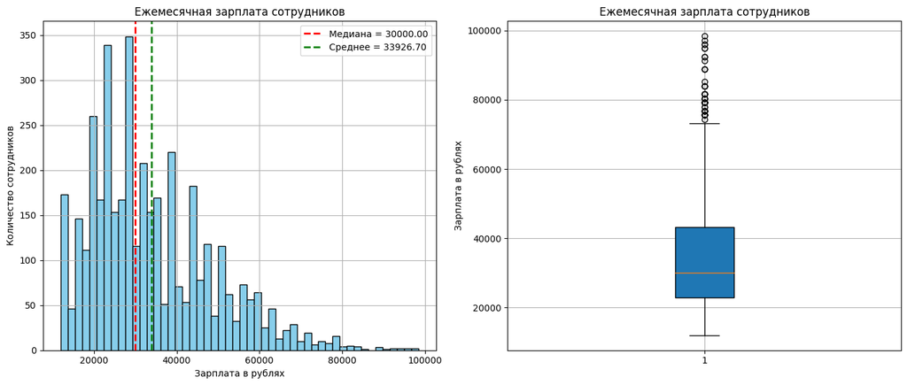

```python
# вызовем функцию для построения гистограммы и диаграммы размаха
hist_boxplot_creation(train_job_satisfaction_rate, 'salary', 50, 'Ежемесячная зарплата сотрудников', 'Количество сотрудников', 'Зарплата в рублях')
```

- Гистограмма показывает распределение с асимметрией вправо. Среднее (**33 926.70**) больше медианы (**30 000**).
- Виден тонкий длинный хвост, тянущийся вправо приблизительно до отметки в **100 000** рублей.
- Диаграмма размаха показывает наличие выбросов ориентировочно от отметки **70 500** до **100 000** рублей.

Отобразим максимальное и минимальное значения в столбце:

```python
# выведем максимальное и минимальное значения в столбце
print(
    f'минимальное значение = {train_job_satisfaction_rate["salary"].min()},\nмаксимальное значение = {train_job_satisfaction_rate["salary"].max()}')
```

```
минимальное значение = 12000,
максимальное значение = 98400
```

Посмотрим на минимальное значение в контексте:

```python
# отобразим строки с минимальной заработной платой - 12 000
train_job_satisfaction_rate.query('salary == 12_000').head(10)
```

|  | id | dept | level | workload | employment_years | last_year_promo | last_year_violations | supervisor_evaluation | salary | job_satisfaction_rate |
| --- | --- | --- | --- | --- | --- | --- | --- | --- | --- | --- |
| 2 | 184592 | sales | junior | low | 1 | no | no | 2 | 12000 | 0.11 |
| 36 | 966840 | purchasing | junior | low | 2 | no | no | 3 | 12000 | 0.35 |
| 52 | 696387 | sales | junior | low | 4 | no | no | 4 | 12000 | 0.60 |
| 62 | 177157 | sales | junior | low | 1 | no | no | 4 | 12000 | 0.46 |
| 112 | 396302 | sales | junior | low | 1 | no | no | 5 | 12000 | 0.45 |
| 148 | 398692 | sales | junior | low | 4 | no | no | 3 | 12000 | 0.35 |
| 190 | 712077 | sales | junior | low | 1 | no | no | 5 | 12000 | 0.56 |
| 243 | 781702 | purchasing | junior | low | 1 | no | no | 3 | 12000 | 0.19 |
| 256 | 876633 | sales | junior | low | 1 | no | no | 3 | 12000 | 0.10 |
| 278 | 716287 | sales | junior | low | 1 | no | no | 2 | 12000 | 0.23 |

```python
# выведем количество наблюдений
train_job_satisfaction_rate.query('salary == 12_000')['id'].count()
```

```
113
```

- **113** сотрудников ежемесячно получают зарплату в размере **12 000** рублей. В таблице видно, что большинство таких сотрудников являются начинающими специалистами с минимальным уровнем нагрузки. Можно предположить, что низкая заработная плата в этом случае связана с частичной занятостью.

Проверим данные о сотрудниках с максимальной зарплатной вилкой, возьмём диапазон от **90 000** до **98 500** рублей:

```python
train_job_satisfaction_rate.query('salary >= 90_000 and salary <= 98_500').head(10)
```

|  | id | dept | level | workload | employment_years | last_year_promo | last_year_violations | supervisor_evaluation | salary | job_satisfaction_rate |
| --- | --- | --- | --- | --- | --- | --- | --- | --- | --- | --- |
| 1241 | 148024 | technology | sinior | high | 4 | no | no | 4 | 94800 | 0.67 |
| 1982 | 978915 | technology | sinior | high | 7 | no | no | 1 | 92400 | 0.45 |
| 2469 | 771794 | technology | sinior | high | 5 | no | yes | 1 | 91200 | 0.24 |
| 2746 | 717479 | technology | sinior | high | 6 | no | no | 3 | 92400 | 0.47 |
| 2750 | 493986 | technology | sinior | high | 9 | yes | no | 4 | 94800 | 0.99 |
| 2845 | 839346 | technology | sinior | high | 5 | no | no | 5 | 98400 | 0.67 |
| 2901 | 930908 | technology | sinior | high | 10 | no | no | 4 | 96000 | 0.92 |
| 3024 | 494924 | technology | sinior | high | 6 | no | no | 4 | 96000 | 0.89 |
| 3839 | 868744 | technology | sinior | high | 5 | yes | no | 4 | 97200 | 0.84 |

- Не будем считать максимальное значение выбросом, так как данные о сотрудниках выглядят реалистично. В среднем специалисты в сфере `информационных технологий` получают более высокую заработную плату по сравнению с представителями других направлений, особенно на уровне `senior`. В 2025 году зарплата в районе **100 000** рублей — это скорее нижняя граница вилки для `старших специалистов`.

Оценим распределение значений в столбце с количественными непрерывными переменными `job_satisfaction_rate`:

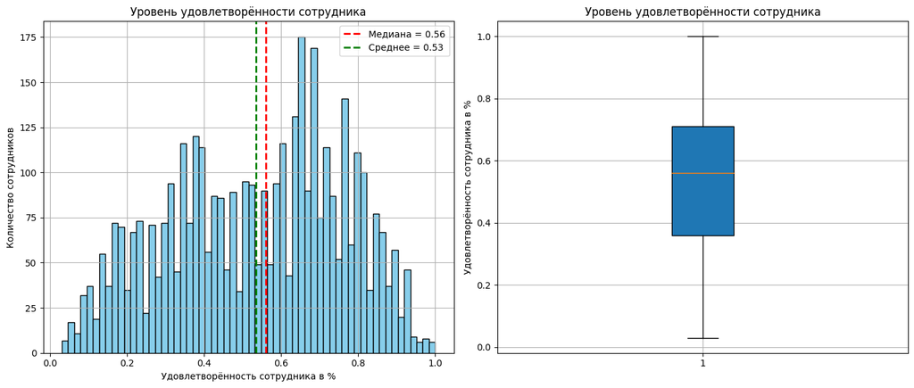

```python
# вызовем функцию для построения гистограммы и диаграммы размаха
hist_boxplot_creation(train_job_satisfaction_rate, 'job_satisfaction_rate', 60, 'Уровень удовлетворённости сотрудника', 'Количество сотрудников', 'Удовлетворённость сотрудника в %')
```

- На гистограмме можно увидеть бимодальное распределение с двумя пиками — ориентировочно у отметок в **35** и **65** %.
- Медиана (**0.56**) незначительно выше среднего (**0.53**).
- Диаграмма размаха показывает отсутствие выбросов в столбце.

**Выводы**:

- Диаграммы размаха показали выбросы в двух столбцах: `supervisor_evaluation` и `salary`.
- Не признали данные выбросами, так как значения соответствуют действительности. В дальнейшем обучим модель на реалистичных данных с отдельными высокими значениями. Это позволит ей лучше справляться с предсказаниями на тестовой выборке, поскольку крупные значения не являются аномалиями и могут встречаться в реальных данных.

#### Анализ таблиц test_features и test_target_job_satisfaction_rate

Проанализируем распределение значений в категориальных столбцах в тестовой выборке `test_features`:

```python
# вызовем функцию для построения столбчатых диаграмм
barplots(test_features)
```

[interactive chart not shown]

- Заметили пустые строки в столбцах `dept` и `workload`. Такие значения будут обработаны в пайплайне с помощью SimpleImputer.
- В целом, графики по категориальным столбцам `test_features` отражают общие тенденции графиков по столбцам тренировочных данных.
- В столбце `dept` поменялись местами категории `marketing` и `purchasing`. В тестовой выборке сотрудников в отделе маркетинга больше, чем в закупках.

Сравним гистограммы по столбцам `employment_years`, `supervisor_evaluation` и `salary` с гистограммами по тем же столбцам в обучающей выборке:

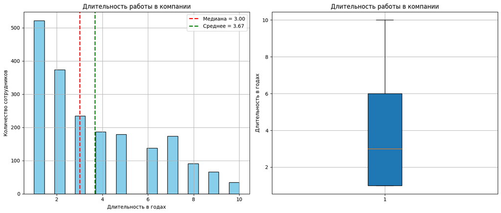

```python
# вызовем функцию
hist_boxplot_creation(test_features, 'employment_years', 20, 'Длительность работы в компании', 'Количество сотрудников', 'Длительность в годах')
```

- Медианное и среднее значения не сильно отклоняются от значений в тренировочной выборке (**3**, **3.72**).
- Диаграмма размаха показывает, что примерный диапазон большинства значений – почти от **года** до **6** лет. В тренировочной выборке – от **2** до **6** лет.

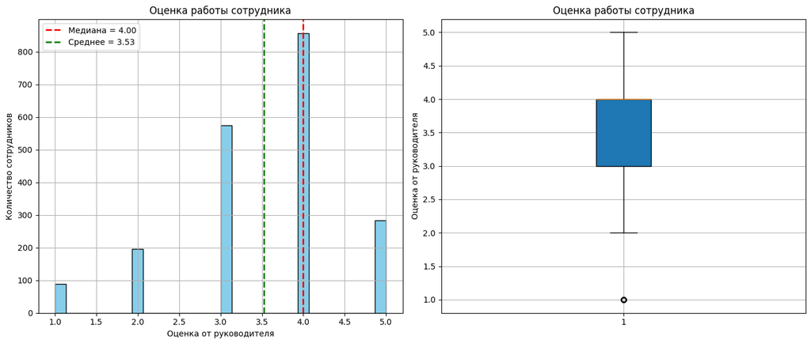

```python
# вызовем функцию
hist_boxplot_creation(test_features, 'supervisor_evaluation', 30, 'Оценка работы сотрудника', 'Количество сотрудников', 'Оценка от руководителя')
```

- Значения в столбце распределены практически также, как в тренировочной выборке. Есть небольшая разница в среднем значении – **3.53** в тестовых и **3.48** в тренировочных данных.
- Диаграмма размаха также обозначила оценку в **1** балл как выброс.

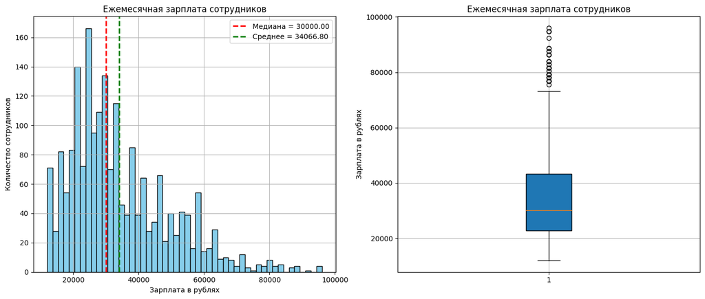

```python
# вызовем функцию
hist_boxplot_creation(test_features, 'salary', 50, 'Ежемесячная зарплата сотрудников', 'Количество сотрудников', 'Зарплата в рублях')
```

- Можно снова заметить небольшую разницу между средним значением в тестовых и тренировочных данных – **34 066.80** и **33 926.70**.
- Диаграмма размаха также показывает выбросы в столбце.

Проанализируем гистограмму и "ящик с усами" по таргету `test_target_job_satisfaction_rate`:

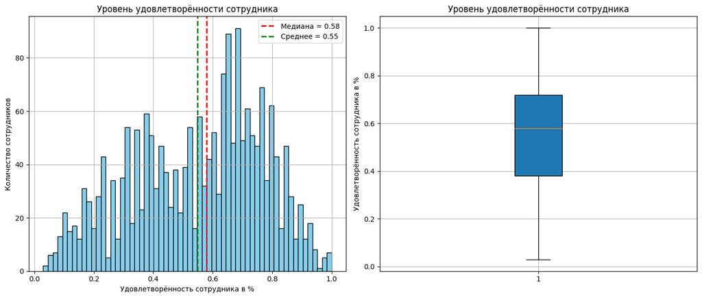

```python
# вызовем функцию для построения гистограммы и диаграммы размаха
hist_boxplot_creation(test_target_job_satisfaction_rate, 'job_satisfaction_rate', 60, 'Уровень удовлетворённости сотрудника', 'Количество сотрудников', 'Удовлетворённость сотрудника в %')
```

- Есть небольшая разница между медианным значением целевой переменной в тренировочной выборке (**0.56**) и тестовой (**0.58**).
- Среднее незначительно отличается: в тренировочной выборке – **0.53** и тестовой – **0.55**.

**Выводы**:

- Графики по категориальным столбцам `test_features` отражают общие тенденции графиков по столбцам тренировочных данных
- Поменялись местами категории `маркетинг` и `закупки`
- В столбцах с числами обнаружена незначительная разница в среднем и медиане. В данных также присутствуют выбросы

#### Анализ таблицы train_quit

Проанализируем распределение признаков в категориальных столбцах тренировочной выборки `train_quit`: `dept`, `level`, `workload`, `last_year_promo`, `last_year_violations` c учётом целевого признака`quit` (`no`/`yes`):

```python
# отберём категориальные признаки датафрейма
cat_cols_bar_quit = train_quit.select_dtypes(include='object').columns.drop('quit')

# обозначим фигуру
fig = go.Figure()

# сгруппируем значения и сформируем таблицу
# посчитаем записи в каждой группе с помощью size()
# поднимем второй уровень индекса quit в колонки c помощью unstack(), вместо nan проставим 0
for i, col in enumerate(cat_cols_bar_quit):
    grouped = train_quit.groupby([col,'quit']).size().unstack(fill_value=0)

    # переберём все значения quit
    for quit_val in grouped.columns:
        # каждую итерацию будем добавлять одну группу столбиков на график(для quit - no и quit - yes)
        fig.add_trace(go.Bar(
            # подпишем категории признака col на оси x
            x=grouped.index,
            y=grouped[quit_val],
            # добавим подпись в легенде
            name=f"{col} - quit({quit_val})",
            # сначала покажем только первый barplot
            visible=(i == 0),
            # добавим подписи над каждым столбиком
            text=grouped[quit_val],
            textposition='outside',
            # отключим параметр, чтобы не обрезался текст за границами графика
            cliponaxis=False
        ))

# создадим набор шагов для интерактивного слайдера
# обозначим список для шагов
steps = []
# переберём все категориальные столбцы
for i, col in enumerate(cat_cols_bar_quit):
    # добавим словарь с шагом для слайдера на графике
    step = dict(
        method='update',
        args=[
            {'visible': [(j // 2) == i for j in range(len(cat_cols_bar_quit)*2)]},
            {'title': {'text': f'Распределение {col} по целевой переменной'}}
        ],
        label=col
    )
    steps.append(step)

# создадим слайдер
sliders = [dict(
    active=0,
    currentvalue={"prefix":"График: "},
    pad={"t":50},
    steps=steps
)]

# настроим внешний вид графика
# добавим слайдер, заголовок
# настроим ширину и высоту, корректное отображение столбцов
fig.update_layout(
    sliders=sliders,
    title={'text':f'Распределение {col} по целевой переменной'},
    height=500,
    width=900,
    barmode='group',
    yaxis_title='Количество сотрудников'
)

# отобразим график
fig.show()
```

[interactive chart not shown]

Дополним информацию таблицей с конверсией уволившихся сотрудников от общего числа сотрудников в категории:

```python
# составим список категориальных столбцов
# создадим словарь для таблицы
cat_cols = ['dept', 'level', 'workload', 'last_year_promo', 'last_year_violations']
quit_share_cat = {}

# напишем цикл для перебора столбцов в датафрейме
for col in cat_cols:
    # сгруппируем каждую категорию по целевому признаку и подсчитаем количество значений
    # уберём вложенную структуру
    cat_grouped = train_quit.groupby([col, 'quit']).size().unstack(fill_value=0)
    # рассчитаем конверсию уволившихся сотрудников по столбцам
    cat_grouped['доля_уволившихся_в_%'] = round(cat_grouped['yes'] / (cat_grouped['no'] + cat_grouped['yes']) * 100, 1)
    # обозначим названия столбцов
    cat_grouped.columns = ['остались', 'уволились', 'доля_уволившихся_в_%']
    # сохраним таблицу в словарь
    quit_share_cat[col] = cat_grouped

# напечатаем таблицу
for col, df in quit_share_cat.items():
    display(f"В {col}", df)
```

```
'В dept'
```

| dept | остались | уволились | доля_уволившихся_в_% |
| --- | --- | --- | --- |
| hr | 348 | 116 | 25.0 |
| marketing | 419 | 163 | 28.0 |
| purchasing | 422 | 166 | 28.2 |
| sales | 1031 | 407 | 28.3 |
| technology | 652 | 276 | 29.7 |

```
'В level'
```

| level | остались | уволились | доля_уволившихся_в_% |
| --- | --- | --- | --- |
| junior | 946 | 1003 | 51.5 |
| middle | 1586 | 108 | 6.4 |
| sinior | 340 | 17 | 4.8 |

```
'В workload'
```

| workload | остались | уволились | доля_уволившихся_в_% |
| --- | --- | --- | --- |
| high | 553 | 121 | 18.0 |
| low | 689 | 519 | 43.0 |
| medium | 1630 | 488 | 23.0 |

```
'В last_year_promo'
```

| last_year_promo | остались | уволились | доля_уволившихся_в_% |
| --- | --- | --- | --- |
| no | 2760 | 1127 | 29.0 |
| yes | 112 | 1 | 0.9 |

```
'В last_year_violations'
```

| last_year_violations | остались | уволились | доля_уволившихся_в_% |
| --- | --- | --- | --- |
| no | 2555 | 900 | 26.0 |
| yes | 317 | 228 | 41.8 |

Самая высокая доля уволившихся сотрудников:

- Находится в `IT` отделе — **29.7** %;
- На уровне `junior` — **51.5** %;
- C **низкой** `нагрузкой` — **43.0** %;
- **Без** `повышения за последний год` — **29** %;
- **C** `нарушением трудового договора за последний год` — **41.8** %.

Самая низкая доля:

- В отделе `hr` — **25** %;
- На позициях уровня `senior` — **4.8** %;
- У сотрудников с **высоким** уровнем нагрузки — **18** %;
- **С** `повышением за последний год` — **0.9** %;
- **Без** `нарушений трудового договора за последний год` — **26** %.

Проанализируем распределение числовых признаков `salary`, `employment_years`, `supervisor_evaluation` с учётом целевого признака `quit:`

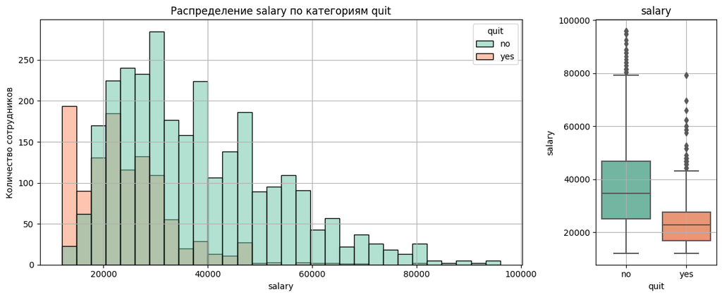

```python
# напишем функцию для построения гистограммы в зависимости от целевого признака quit и диаграммы размаха
def hist_boxplot_quit(column):

    # зададим количество строк и столбцов подграфиков, пропорции ширины у двух графиков
    fig, axes = plt.subplots(1,2, figsize=(12,5), gridspec_kw={'width_ratios':[4,1]})

    # построим гистограмму с учетом таргета - quit
    # выберем столбец и укажем количество корзин
    # настроим прозрачность заливки гистограммы
    # отключим кривую kde и common_norm
    sns.histplot(
        data=train_quit,
        x=column,
        hue='quit',
        bins=30,
        alpha=0.5,
        palette='Set2',
        kde=False,
        common_norm=False,
        ax=axes[0]
    )

    # обозначим название графика, подпишем оси
    # добавим сетку
    axes[0].set_title(f'Распределение {column} по категориям quit')
    axes[0].set_xlabel(column)
    axes[0].set_ylabel('Количество сотрудников')
    axes[0].grid(True)

    # построим boxplot()
    sns.boxplot(
        data=train_quit,
        y=column,
        x='quit',
        palette='Set2',
        ax=axes[1]
    )

    axes[1].set_title(column)
    axes[1].set_ylabel(column)
    axes[1].grid(True)

    # добавим tight_layout() для автоматического размещения элементов
    # выведем график
    plt.tight_layout()
    plt.show()

# вызовем функцию
hist_boxplot_quit('salary')
```

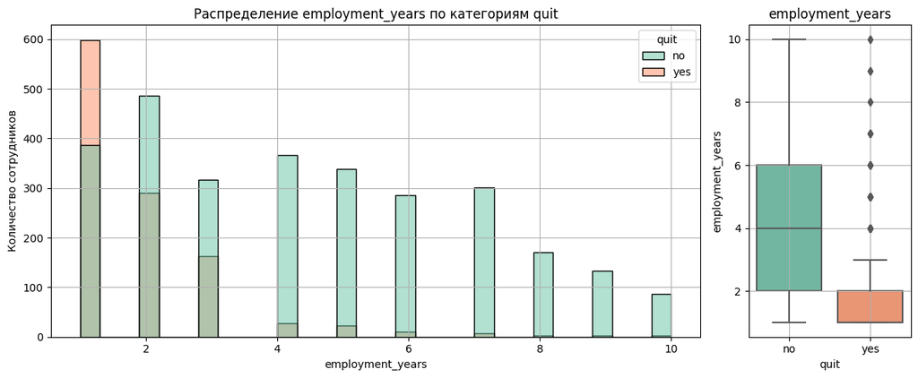

```python
# вызовем функцию для построения гистограммы и boxplot() с учетом таргета quit
hist_boxplot_quit('employment_years')
```

- `Трудовой стаж` сотрудников `с вероятным увольнением` преимущественно составляет от **1** до **2** лет. Далее количество сотрудников снижается до отметки в **3** года и значения тянутся в виде тонкого хвоста из выбросов от отметки в **4** года до **10** лет. Такое распределение может говорить о высокой текучке кадров с небольшим трудовым стажем.
- Сотрудники, которые `останутся в компании`, распределены более равномерно. В основном, такие сотрудники работают в компании от **2** до **6** лет. Диаграмма размаха показывает отсутствие выбросов в этой категории.

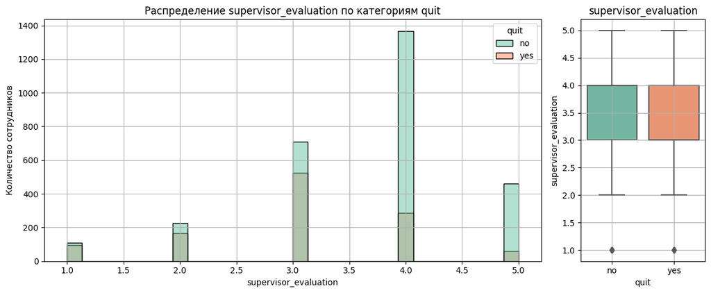

```python
# вызовем функцию для построения hist() и boxplot() с учётом таргета
hist_boxplot_quit('supervisor_evaluation')
```

Исследуем взаимосвязь между уровнем удовлетворённости сотрудника работой в компании и фактом его увольнения. Визуализируем и сравним распределения признака `job_satisfaction_rate` для ушедших и оставшихся сотрудников. Используем данные с целевыми признаками тестовой выборки.

Выведем размерность датафреймов до объединения:

```python
# выведем размерность датафрейма test_target_job_satisfaction_rate
test_target_job_satisfaction_rate.shape
```

```
(2000, 2)
```

```python
# выведем размерность таблицы test_target_quit
test_target_quit.shape
```

```
(2000, 2)
```

Объдиним таблицы:

```python
# объединим таблицы с таргетами job_satisfaction_rate и quit
job_satisfaction_rate_and_quit = test_target_job_satisfaction_rate.merge(test_target_quit, on='id', how='outer')

# проверим результат, выведем первые 10 строк датафрейма
job_satisfaction_rate_and_quit.head(10)
```

|  | id | job_satisfaction_rate | quit |
| --- | --- | --- | --- |
| 0 | 100298 | 0.80 | no |
| 1 | 100480 | 0.84 | no |
| 2 | 100503 | 0.79 | no |
| 3 | 100610 | 0.75 | no |
| 4 | 100692 | 0.69 | no |
| 5 | 100710 | 0.68 | no |
| 6 | 100894 | 0.49 | no |
| 7 | 102102 | 0.73 | no |
| 8 | 102222 | 0.66 | no |
| 9 | 102320 | 0.26 | no |

Выведем размерность итогового датафрейма:

```python
# выведем размерность датафрейма после объединения
job_satisfaction_rate_and_quit.shape
```

```
(2000, 3)
```

Построим гистограмму по столбцу `job_satisfaction_rate` c учётом категорий в `quit`:

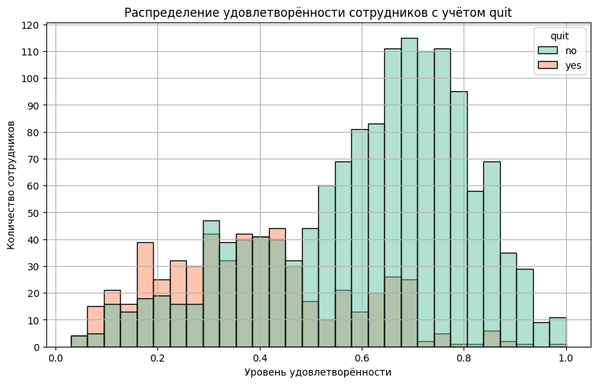

```python
# построим гистограмму с помощью seaborn
fig, ax = plt.subplots(figsize=(10,6))
sns.histplot(
    data=job_satisfaction_rate_and_quit,
    x='job_satisfaction_rate',
    hue='quit',
    bins=30,
    alpha=0.5,
    palette='Set2',
    kde=False,
    common_norm=False,
    ax=ax
)

# обозначим название графика
# подпишем оси x и y
# проставим метки на оси y с шагом 10
# добавим сетку
ax.set_title('Распределение удовлетворённости сотрудников с учётом quit')
ax.set_ylabel('Количество сотрудников')
ax.set_xlabel('Уровень удовлетворённости')
ax.set_yticks(range(0,130,10))
ax.grid(True)
```

- На гистограмме видно, что с увеличением уровня удовлетворённости уменьшается количество уволившихся сотрудников. Пик увольнений приходится на уровень удовлетворённости около **30** %, после чего количество увольнений сокращается. Длинный тонкий хвост показывает, что лишь небольшое количество сотрудников увольняется с удовлетворённостью работой в компании в диапазоне от **70** до **100** %.
- Также можно увидеть обратную тенденцию: с увеличением уровня удовлетворённости растёт количество сотрудников, которые продолжают работать в компании.

**Выводы**:

- Согласно диаграммам размаха с учётом целевого признака `quit`(`yes`/`no`) в столбцах `salary`, `employment_years` и `supervisor_evaluation` присутствуют выбросы.
- Не будем фильтровать данные в столбцах, так как возможен риск получить более высокую оценку качества модели на тренировочных данных, чем на тестовых.

#### Анализ таблицы test_target_quit

Посмотрим, как распределены значения в столбце `quit` в тестовом датафрейме:

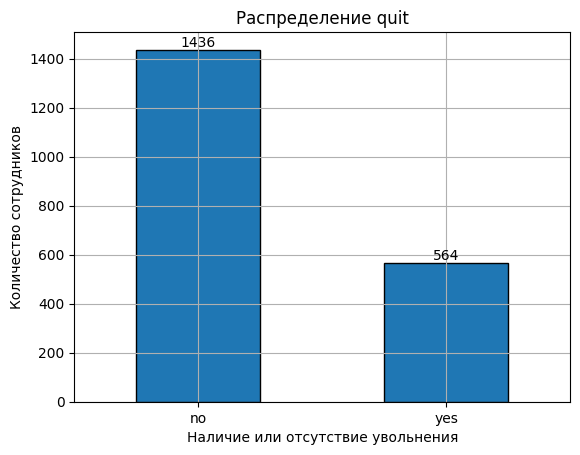

```python
# построим столбчатую диаграмму
counts = test_target_quit['quit'].value_counts()
ax = counts.plot(kind='bar', edgecolor='black')

# добавим подписи над столбиками
for i, value in enumerate(counts.values):
    ax.text(i, value + 1, str(value), ha='center', va='bottom', fontsize=10)

# добавим название и подписи
plt.title('Распределение quit')
plt.ylabel('Количество сотрудников')
plt.xlabel('Наличие или отсутствие увольнения')
plt.grid(True)
plt.xticks(rotation=0)
plt.show()
```

- В данных гораздо больше сотрудников, которые предпочитают продолжить работу в компании. Увольняется всего **28** % сотрудников.

### Статистический анализ: вывод

Проанализировали распределение значений в столбцах с категориальными и числовыми переменными в тренировочных выборках `train_job_satisfaction_rate` и `train_quit`. Не признали редкие крупные значения выбросами, так как они соответствуют действительности.

Ознакомились с распределением значений в тестовых выборках:

- Графики по категориальным столбцам `test_features` отражают общие тенденции графиков по столбцам тренировочных данных. В столбцах с числами обнаружена незначительная разница в среднем и медиане. В данных также присутствуют выбросы

Выявили характеристики сотрудника с высоким и низким уровнем удовлетворённости:

- Самый **высокий** уровень удовлетворённости можно заметить у сотрудников в отделе `продаж` на уровне `senior`, c `низким уровнем нагрузки`, `с повышением` за последний год и `отсутствием нарушений` трудового договора за последний год — **0.97**;
- Самый **низкий** уровень удовлетворённости у сотрудников: в отделе `hr` на уровне `junior`, c `высоким уровнем нагрузки`, `без повышения` за последний год и с `наличием нарушений` трудового договора за последний год — **0.09**.

Составили портрет уволившегося сотрудника и сотрудника, который продолжает работу в компании:

Исследовали взаимосвязь между уровнем удовлетворённости сотрудника и фактом его увольнения:

- С увеличением уровня удовлетворённости уменьшается количество уволившихся сотрудников.
- С увеличением уровня удовлетворённости растёт количество сотрудников, которые продолжают работать в компании.

### Корреляционный анализ признаков

- Рассчитаем коэффициенты корреляции между входными и целевыми признаками тренировочных выборок.
- Проверим, существует ли линейная или нелинейная связь между входными и целевыми признаками.
- Отберём признаки для обучения моделей и сделаем выводы об их подготовке.

#### Анализ таблицы train_job_satisfaction_rate

Рассчитаем коэффициенты корреляции между входными категориальными и числовыми признаками датафрейма.

Для этого построим `phik_matrix`, так как она устойчива к выбросам:

```
interval columns not set, guessing: ['id', 'employment_years', 'supervisor_evaluation', 'salary', 'job_satisfaction_rate']
```

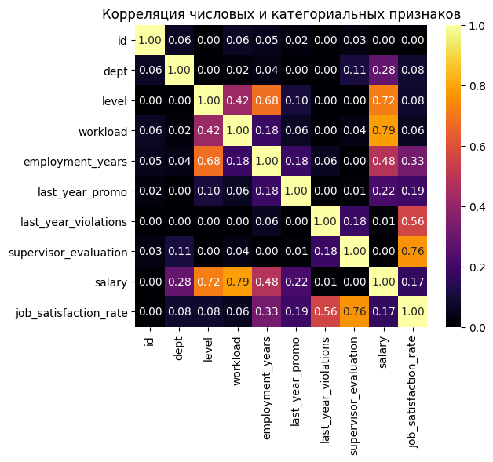

```python
# напишем функцию для построения матрицы корреляций phik_matrix()
def phik_matrix_build(data, value_1, value_2):
    data_phik = data.phik_matrix()
    # визуализируем результат с помощью тепловой карты
    plt.figure(figsize=(value_1, value_2))
    sns.heatmap(data_phik, annot=True, fmt='.2f', cmap='inferno', vmin=0, vmax=1)
    plt.title('Корреляция числовых и категориальных признаков')
    plt.show()

# вызовем функцию и выведем результат
phik_matrix_build(train_job_satisfaction_rate, 6, 5)
```

- Между признаками отсутствует мультиколлинеарность со значением коэффициентов от **0.9**.

С таргетом `job_satisfaction_rate` коррелируют категориальные признаки:

- `last_year_violations` — **0.56**
- `last_year_promo` — **0.19**
- `dept` — **0.08**
- `level` — **0.08**
- `workload` — **0.06**

А также числовые:

- `supervisor_evaluation` — **0.76**
- `employment_years` — **0.33**
- `salary` — **0.17**

Проверим числовые признаки на наличие линейной или нелинейной связи с таргетом с помощью диаграммы рассеяния:

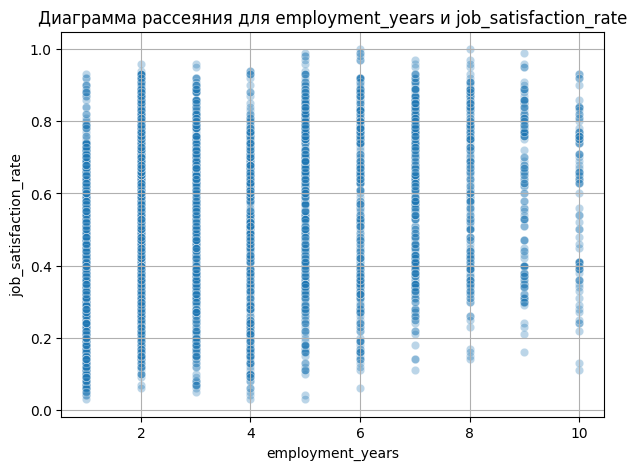

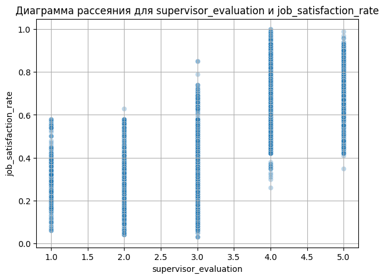

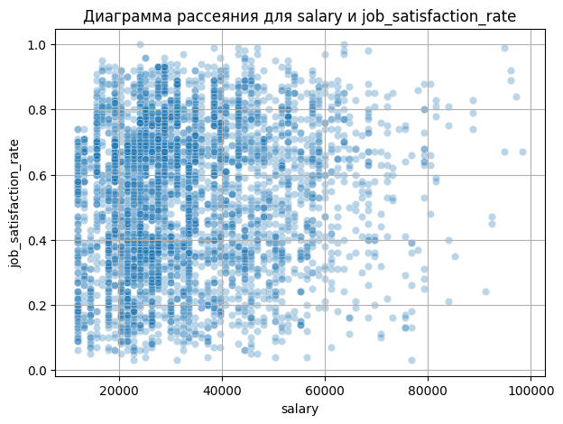

```python
# напишем функцию для построения scatterplot для каждого числового признака и таргета
def scatterplot_build(data, target, drop_columns):
    numeric_columns = data.select_dtypes(include='number').drop(columns=drop_columns).columns
    for column in numeric_columns:
        plt.figure(figsize=(7,5))
        sns.scatterplot(data=data, x=column, y=target, alpha=0.3)
        plt.title(f'Диаграмма рассеяния для {column} и {target}')
        plt.grid(True)
        plt.show()

# вызовем функцию и выведем результат на экран
scatterplot_build(train_job_satisfaction_rate, 'job_satisfaction_rate', ['id', 'job_satisfaction_rate'])
```

Для обучения модели при решении задачи регрессии будем использовать признаки:

```python
# выведем общую информацию о выборке
train_job_satisfaction_rate.info()
```

```
<class 'pandas.core.frame.DataFrame'>
RangeIndex: 4000 entries, 0 to 3999
Data columns (total 10 columns):
 #   Column                 Non-Null Count  Dtype
---  ------                 --------------  -----
 0   id                     4000 non-null   int64
 1   dept                   3994 non-null   object
 2   level                  3996 non-null   object
 3   workload               4000 non-null   object
 4   employment_years       4000 non-null   int64
 5   last_year_promo        4000 non-null   object
 6   last_year_violations   4000 non-null   object
 7   supervisor_evaluation  4000 non-null   int64
 8   salary                 4000 non-null   int64
 9   job_satisfaction_rate  4000 non-null   float64
dtypes: float64(1), int64(4), object(5)
memory usage: 312.6+ KB
```

- `job_satisfaction_rate` — целевой признак.
- Категориальные признаки как c умеренным, так и с низким коэффициентом корреляции по причине небольшого количества признаков со средней или высокой корреляцией от **0.17** до **0.76**.
- Числовые признаки: supervisor_evaluation (**0.76**), employment_years (**0.33**), salary (**0.17**).

Подготовим признаки следующими способами:

- Столбцы с категориальными номинальными переменными `dept`, `last_year_promo`, `last_year_violations` закодируем с помощью **OneHotEncoder**.
- Признаки с логическим порядком `level` и `workload`закодируем с помощью **OrdinalEncoder**.
- Для масштабирования количественных признаков используем несколько вариантов: масштабирование **MinMaxScaler()**, стандартизация **StandardScaler()** и робастное масштабирование **RobustScaler()**. Переберём их как гиперпараметры для модели `Линейной регрессии`, так как `Дерево решений` не чувствительно к масштабу признаков.

#### Анализ таблицы train_quit

Проанализируем корреляцию входных категориальных и числовых признаков датафрейма:

```
interval columns not set, guessing: ['id', 'employment_years', 'supervisor_evaluation', 'salary']
```

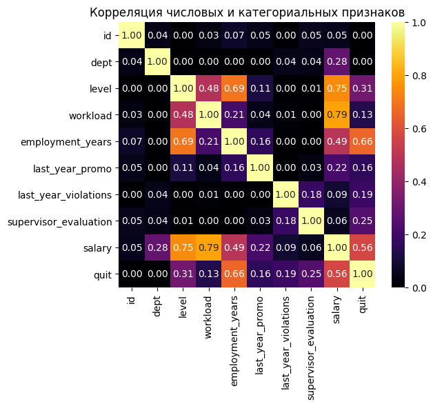

```python
# вызовем функцию и выведем результат
phik_matrix_build(train_quit, 6, 5)
```

- Между признаками отсутствует мультиколлинеарность.

С целевым признаком `quit` коррелируют категориальные признаки:

- `level` — **0.31**
- `last_year_violations` — **0.19**
- `last_year_promo` — **0.16**
- `workload` — **0.13**

А также числовые:

- `employment_years` — **0.66**
- `salary` — **0.56**
- `supervisor_evaluation`— **0.25**

Для обучения модели при решении задачи категоризации:

- Будем использовать все признаки, перечисленные выше. Не будем использовать `dept` с нулевой корреляцией, чтобы избежать шума.
- Обработаем пропуски с помощью **SimpleImputer**.
- Категориальные признаки `level` и `workload` закодируем с помощью **OrdinalEncoder**, а `last_year_violations` и `last_year_promo` — **OneHotEncoder**.
- Для масштабирования количественных признаков используем в пайплайне три варианта: **MinMaxScaler()**, **StandardScaler()**, **RobustScaler()**.

Если `job_satisfaction_rate` и `quit` действительно связаны и мы получим необходимое значение метрики в результате решения первой задачи — добавим `job_satisfaction_rate`, предсказанный лучшей моделью первой задачи, к входным признакам второй задачи.

## Решение задачи регрессии

### Создание пайплайна

Подготовим пайплайн для обучения двух моделей — `LinearRegression` и `DecisionTreeRegressor`. Подберём гиперпараметры для моделей с помощью случайного поиска комбинаций `RandomizedSearchCV`. Этот метод оптимален при большом количестве гиперпараметров модели и работает быстрее, чем GridSearchCV.

Выберем лучшую модель с помощью собственной метрики SMAPE, которая вычисляется по формуле:

$$ \text{SMAPE} = \frac{100}{n} \sum_{i=1}^{n} \frac{|y_i - \hat{y}_i|}{\left( |y_i| + |\hat{y}_i| \right) / 2} $$

Напишем функцию, которая принимает на вход массивы NumPy или объекты Series в pandas и возвращает значение метрики SMAPE:

```python
# напишем собственную функцию для создания метрики
def smape(y_true, y_pred):
    y_true, y_pred = np.array(y_true), np.array(y_pred)
    denominator = (np.abs(y_true) + np.abs(y_pred)) / 2
    denominator = np.where(denominator == 0, 1e-8, denominator)
    diff = np.abs(y_true - y_pred)
    smape_values = diff / denominator
    return np.mean(smape_values) * 100

# оборачиваем функцию в make_scorer
# чем меньше метрика - тем лучше
smape_scorer = make_scorer(smape, greater_is_better=False)
```

Соберём пайплайн:

```python
# обозначим, какие данные требуют кодирования
ohe_columns = [
    'dept',
    'last_year_promo',
    'last_year_violations'
]

ord_columns = [
    'level',
    'workload'
]

# обозначим, какие данные требуют масштабирования
num_columns = [
    'supervisor_evaluation',
    'employment_years',
    'salary'
]

# добавляем ohe-кодирование в пайплайн и заполняем пропуски
ohe_pipe = Pipeline([
    ('simpleImputer_before_ohe', SimpleImputer(strategy='most_frequent')),
    ('ohe', OneHotEncoder(handle_unknown='ignore', drop='first')),
    ('simpleImputer_after_ohe', SimpleImputer(strategy='most_frequent'))
])

# добавляем ordinal-кодирование в пайплайн, заполняем пропуски
ord_pipe = Pipeline([
    ('simpleImputer_before_ord', SimpleImputer(strategy='most_frequent')),
    ('ord', OrdinalEncoder(
        categories=[['junior', 'middle', 'senior'], ['low', 'medium', 'high']],
        handle_unknown='use_encoded_value',
        unknown_value=np.nan
    )),
    ('simpleImputer_after_ord', SimpleImputer(strategy='most_frequent'))
])

# объединяем шаги масштабирования и кодирования
data_preprocessor = ColumnTransformer(
    [
        ('ohe', ohe_pipe, ohe_columns),
        ('ord', ord_pipe, ord_columns),
        ('num', MinMaxScaler(), num_columns)
    ],
# проигнорируем и уберем остальные столбцы
    remainder='drop'
)

# создадим итоговый пайплайн для обучения моделей
pipe_final = Pipeline([
    ('pass', pass_processing),
    ('typo', typo_corrector),
    ('preprocessor', data_preprocessor),
    ('models', LinearRegression())
])

# создадим словари с гиперпараметрами моделей
param_distributions = [
# словарь для LinearRegression()
    {
        'models': [LinearRegression()],
        'preprocessor__num': [StandardScaler(), MinMaxScaler(), RobustScaler(), 'passthrough']
    },
# словарь для DecisionTreeRegressor()
    {
        'models': [DecisionTreeRegressor(random_state=RANDOM_STATE)],
        'models__max_depth': range(3, 21),
        'models__max_features': [None, 'sqrt', 'log2', 2, 3, 4],
        'models__min_samples_leaf': range(1,11),
        'models__min_samples_split': range(2,21),
        'models__splitter': ['best', 'random'],
        'preprocessor__num': ['passthrough']

    }
]

# переберём гиперпараметры по сетке RandomizedSearchCV()
search = RandomizedSearchCV(
        pipe_final,
        param_distributions=param_distributions,
        n_iter=50,
        cv=5,
        scoring=smape_scorer,
        random_state=RANDOM_STATE,
        n_jobs=-1,
        verbose=1
)
```

### Обучение моделей

Чтобы избежать ошибок в предсказаниях:

- Отсортируем все 3 датафрейма по id
- Удалим признак id, из-за которого возможна утечка данных и переобучение модели
- Удалим строки-дубликаты

```python
# отсортируем тренировочную выборку, тестовую выборку и таргет по id
# обучающая выборка
train_job_satisfaction_rate = train_job_satisfaction_rate.sort_values(by='id')

# тестовая выборка и таргет
test_features = test_features.sort_values(by='id')
test_target_job_satisfaction_rate = test_target_job_satisfaction_rate.sort_values(by='id')

# удалим признак id
train_job_satisfaction_rate = train_job_satisfaction_rate.drop(columns='id')
test_features = test_features.drop(columns='id')

# удалим дубликаты
# обучающая выборка
train_job_satisfaction_rate = train_job_satisfaction_rate.drop_duplicates()

# тестовая (фичи и таргет)
test = test_features.copy()
test['job_satisfaction_rate'] = test_target_job_satisfaction_rate['job_satisfaction_rate'].values
test = test.drop_duplicates()

# обратно разделим
test_features_clean = test.drop(columns='job_satisfaction_rate')
test_target_clean = test['job_satisfaction_rate']
```

Обучим пайплайн. Выберем лучшую модель и её параметры:

```python
# входные признаки и целевой для обучения
X_train = train_job_satisfaction_rate.drop(columns='job_satisfaction_rate')
y_train = train_job_satisfaction_rate['job_satisfaction_rate']

# обучаем
search.fit(X_train, y_train)
best_model = search.best_estimator_

f'Лучшая модель на валидации и её параметры:', best_model,
```

```
Fitting 5 folds for each of 50 candidates, totalling 250 fits
```

```
('Лучшая модель на валидации и её параметры:',
 Pipeline(steps=[('pass',
                  ColumnTransformer(remainder='passthrough',
                                    transformers=[('fill_pass_categorial',
                                                   Pipeline(steps=[('simple_imputer_cat',
                                                                    SimpleImputer(strategy='most_frequent'))]),
                                                   ['dept', 'level'])],
                                    verbose_feature_names_out=False)),
                 ('typo',
                  FunctionTransformer(func=<function fix_typo_level at 0x000002514EDBD4C0>)),
                 ('preprocessor',
                  ColumnTransforme...
                                                                                               ['low',
                                                                                                'medium',
                                                                                                'high']],
                                                                                   handle_unknown='use_encoded_value',
                                                                                   unknown_value=nan)),
                                                                   ('simpleImputer_after_ord',
                                                                    SimpleImputer(strategy='most_frequent'))]),
                                                   ['level', 'workload']),
                                                  ('num', 'passthrough',
                                                   ['supervisor_evaluation',
                                                    'employment_years',
                                                    'salary'])])),
                 ('models',
                  DecisionTreeRegressor(max_depth=15, min_samples_leaf=4,
                                        min_samples_split=3, random_state=42))]))
```

Лучше всего с предсказанием справилась модель `DecisionTreeRegresor` с параметрами:

- `max_depth` = **15**
- `min_samples_leaf` = **4**
- `min_samples_split` = **3**

Посмотрим на метрику smape:

```python
# добавим знак минус, т.к. sklearn инвертирует знак
f'Метрика лучшей модели на валидации', round(- search.best_score_, 2)
```

```
('Метрика лучшей модели на валидации', 15.38)
```

Модель получила оптимальную оценку и готова к использованию на тестовых данных.

Ознакомимся с рейтингом из 10 моделей, которые показали высокий результат:

```python
# выведем результаты обучения 10 лучших моделей с самым низким значением smape
pd.DataFrame(search.cv_results_)[['rank_test_score', 'param_models', 'mean_test_score', 'params']].sort_values(by='rank_test_score').head(10)
```

|  | rank_test_score | param_models | mean_test_score | params |
| --- | --- | --- | --- | --- |
| 19 | 1 | DecisionTreeRegressor(random_state=42) | -15.381506 | {'preprocessor__num': 'passthrough', 'models__... |
| 14 | 2 | DecisionTreeRegressor(random_state=42) | -17.208322 | {'preprocessor__num': 'passthrough', 'models__... |
| 20 | 3 | DecisionTreeRegressor(random_state=42) | -18.383109 | {'preprocessor__num': 'passthrough', 'models__... |
| 2 | 4 | DecisionTreeRegressor(random_state=42) | -18.438881 | {'preprocessor__num': 'passthrough', 'models__... |
| 46 | 5 | DecisionTreeRegressor(random_state=42) | -18.774242 | {'preprocessor__num': 'passthrough', 'models__... |
| 44 | 6 | DecisionTreeRegressor(random_state=42) | -19.109882 | {'preprocessor__num': 'passthrough', 'models__... |
| 22 | 7 | DecisionTreeRegressor(random_state=42) | -19.566136 | {'preprocessor__num': 'passthrough', 'models__... |
| 25 | 8 | DecisionTreeRegressor(random_state=42) | -19.612134 | {'preprocessor__num': 'passthrough', 'models__... |
| 5 | 9 | DecisionTreeRegressor(random_state=42) | -19.620139 | {'preprocessor__num': 'passthrough', 'models__... |
| 15 | 10 | DecisionTreeRegressor(random_state=42) | -19.634391 | {'preprocessor__num': 'passthrough', 'models__... |

В топ-10 оказались только модели `DecisionTreeRegressor` со значением smape от **19.63** до **15.38**. Это можно объяснить тем, что `Деревья решений` устойчивы к выбросам в данных, в отличие от `Линейной регрессии`. Также для `Дерева` не важно наличие линейной связи между входными и целевым признаками.

Предскажем целевой признак на тестовых данных:

```python
# выберем подготовленный таргет
y_true = test_target_clean

# сделаем прогноз на тестовой выборке
y_pred = best_model.predict(test_features_clean)

print(round(smape(y_true, y_pred), 2))
```

```
13.8
```

### Анализ важности признаков

Оценим важность признаков лучшей модели.

Ознакомимся с влиянием каждого признака на любой прогноз модели, построим график `shap.summary_plot`:

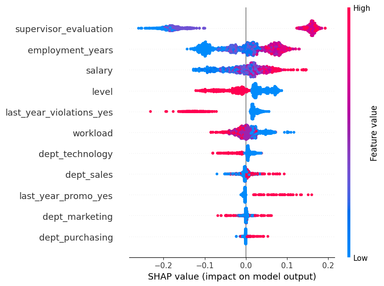

```python
# достаём лучшую модель DecisionTreeRegressor из пайплайна best_model
model = best_model.named_steps['models']

# возьмём preprocessor из пайплайна для предобработки тестовых данных
# обработаем тестовые данные как на обучении
X_test_processed = best_model.named_steps['preprocessor'].transform(test_features_clean)

# получим имена признаков после ohe
# для удобства сохраним preprocessor в отдельную переменную
# достанем из preprocessor ohe
# получим имена новых признаков после ohe, т.к. ohe возвращает бинарные столбцы на каждый признак
preprocessor = best_model.named_steps['preprocessor']
ohe = preprocessor.named_transformers_['ohe'].named_steps['ohe']
feature_names_ohe = ohe.get_feature_names_out(ohe_columns)

# объединяем все названия признаков (ohe, ord, num)
all_feature_names = np.concatenate([
    feature_names_ohe,
    ord_columns,
    num_columns
])

# создадим shap explainer
# TreeExplainer объяснит, как дерево принимает решение
explainer = shap.TreeExplainer(model)

# посчитаем shap values - вклад каждого признака в финальное предсказание
shap_values = explainer.shap_values(X_test_processed)

# напечатаем summary_plot
shap.summary_plot(shap_values, X_test_processed, feature_names=all_feature_names)
```

## Решение задачи классификации

### Подготовка данных

Подготовим выборки к обучению:

```python
# отсортируем train и target по id
train_quit = train_quit.sort_values('id').reset_index(drop=True)
test_target_quit = test_target_quit.sort_values('id').reset_index(drop=True)

# сохраним выборки в переменные для удобства
# удалим id в train, который может создать шум
# используем test_features без id из первого задания
y_train = train_quit['quit']
X_train = train_quit.drop(columns=['quit', 'id'])
y_test = test_target_quit['quit']
X_test = test_features.copy()

# предскажем на тренировочных входных данных признак job_satisfaction_rate с помощью регрессора best_model
# сделаем предсказание на тестовых данных
job_satisfaction_pred_train = best_model.predict(X_train)
job_satisfaction_pred_test = best_model.predict(X_test)

# добавим предсказанный признак в тренировочную и тестовую выборку, чтобы избежать ошибки несоответствия количества столбцов при дальнейших расчетах
X_train['job_satisfaction_rate'] = job_satisfaction_pred_train
X_test['job_satisfaction_rate'] = job_satisfaction_pred_test
```

### Создание пайплайна

Добавим в пайплайн 4 модели для решения задачи классификации: `SVC`, `DecisionTreeClassifier`, `LogisticRegression` , `kNN`:

```python
# отметим, какие признаки для кодирования, а какие для масштабирования/стандартизации
# добавим job_satisfaction_rate
ohe_columns_2 = ['last_year_violations', 'last_year_promo']
ord_columns_2 = ['level', 'workload']
num_columns_2 = ['employment_years', 'salary', 'supervisor_evaluation', 'job_satisfaction_rate']

# соберём пайплайны для кодирования и масштабирования
ohe_pipe_2 = Pipeline([
    ('imputer', SimpleImputer(strategy='most_frequent')),
    ('ohe', OneHotEncoder(handle_unknown='ignore', drop="first"))
])

# заполним неизвестные значения модой
ord_pipe_2 = Pipeline([
    ('imputer', SimpleImputer(strategy='most_frequent')),
    ('ord', OrdinalEncoder(
        categories=[['junior', 'middle', 'senior'], ['low', 'medium', 'high']],
        handle_unknown='use_encoded_value',
        unknown_value=-1
    ))
])

# заполним неизвестные значения медианой
num_pipe_2 = Pipeline([
    ('imputer', SimpleImputer(strategy='median')),
    ('scaler', MinMaxScaler())
])

data_preprocessor_2 = ColumnTransformer(
    transformers=[
        ('ohe', ohe_pipe_2, ohe_columns_2),
        ('ord', ord_pipe_2, ord_columns_2),
        ('num', num_pipe_2, num_columns_2),
    ],
    remainder='drop'
)

# соберём финальный пайплайн с моделями
pipe_final_2 = Pipeline([
    ('pass', pass_processing),
    ('typo', typo_corrector),
    ('preprocessor', data_preprocessor_2),
    ('models', DecisionTreeClassifier(random_state=RANDOM_STATE))
])

# укажем иперпараметры для RandomizedSearchCV с 4 моделями
param_random_2 = [
# словарь для DecisionTreeClassifier
    {
        'models': [DecisionTreeClassifier(random_state=RANDOM_STATE)],
        'models__max_depth': range(2, 15),
        'models__max_features': range(2, 10),
    },
# словарь для kNN
    {
        'models': [KNeighborsClassifier()],
        'models__n_neighbors': range(2, 15),
        'preprocessor__num__scaler': [StandardScaler(), MinMaxScaler(), RobustScaler(), 'passthrough']
    },
# словарь для LogisticRegression
    {
        'models': [LogisticRegression(random_state=RANDOM_STATE, solver='liblinear')],
        'models__penalty': ['l1', 'l2'],
        'models__C': np.logspace(-3, 3, 10),
        'preprocessor__num__scaler': [StandardScaler(), MinMaxScaler(), RobustScaler(), 'passthrough']
    },
# словарь для SVC
    {
        'models': [SVC(random_state=RANDOM_STATE, probability=True)],
        'models__kernel': ['linear', 'rbf', 'poly'],
        'preprocessor__num__scaler': [StandardScaler(), MinMaxScaler(), RobustScaler(), 'passthrough']
    }
]

# переберём гиперпараметры с RandomizedSearchCV
# будем считать метрику roc-auc
random_search_2 = RandomizedSearchCV(
    pipe_final_2,
    param_distributions=param_random_2,
    n_iter=30,
    cv=5,
    scoring='roc_auc',
    random_state=RANDOM_STATE,
    n_jobs=-1,
    verbose=2
)
```

### Обучение моделей

Обучим 4 модели и выведем лучшую по оценке `roc_auc`:

```python
# обучим RandomizedSearchCV
random_search_2.fit(X_train, y_train)

# лучшая модель и параметры
best_model_2 = random_search_2.best_estimator_
print('Лучшая модель и параметры:', best_model_2)
```

```
Fitting 5 folds for each of 30 candidates, totalling 150 fits
Лучшая модель и параметры: Pipeline(steps=[('pass',
                 ColumnTransformer(remainder='passthrough',
                                   transformers=[('fill_pass_categorial',
                                                  Pipeline(steps=[('simple_imputer_cat',
                                                                   SimpleImputer(strategy='most_frequent'))]),
                                                  ['dept', 'level'])],
                                   verbose_feature_names_out=False)),
                ('typo',
                 FunctionTransformer(func=<function fix_typo_level at 0x000002514EDBD4C0>)),
                ('preprocessor',
                 ColumnTransforme...
                                                                                               'medium',
                                                                                               'high']],
                                                                                  handle_unknown='use_encoded_value',
                                                                                  unknown_value=-1))]),
                                                  ['level', 'workload']),
                                                 ('num',
                                                  Pipeline(steps=[('imputer',
                                                                   SimpleImputer(strategy='median')),
                                                                  ('scaler',
                                                                   MinMaxScaler())]),
                                                  ['employment_years', 'salary',
                                                   'supervisor_evaluation',
                                                   'job_satisfaction_rate'])])),
                ('models',
                 DecisionTreeClassifier(max_depth=5, max_features=8,
                                        random_state=42))])
```

Лучшая модель — **DecisionTreeClassifier** c комбинацией гиперпараметров:

- max_depth=5
- max_features=8

Возможная причина состоит в том, что дерево решений не предполагает наличия линейной зависимости между признаками и целевой переменной, а также обладает высокой устойчивостью к выбросам и шуму.

Посмотрим на метрику ROC-AUC на валидации и тесте:

```python
# метрика ROC-AUC на тренировочных данных
y_train_proba = best_model_2.predict_proba(X_train)[:, 1]
roc_auc_train = roc_auc_score(y_train, y_train_proba)
print(f'ROC-AUC на валидации: {roc_auc_train:.2f}')

# метрика ROC-AUC на тесте
y_test_proba = best_model_2.predict_proba(X_test)[:, 1]
roc_auc_test = roc_auc_score(y_test, y_test_proba)
print(f'ROC-AUC на тесте: {roc_auc_test:.2f}')
```

```
ROC-AUC на валидации: 0.95
ROC-AUC на тесте: 0.93
```

Модель показала оптимальный результат на тестовых данных — **93**

Посмотрим, какие модели входят в топ-10:

```python
# выведем результаты обучения 10 лучших моделей с самым высоким значением roc-auc
pd.DataFrame(random_search_2.cv_results_)[['rank_test_score', 'param_models', 'mean_test_score', 'params']].sort_values(by='rank_test_score').head(10)
```

|  | rank_test_score | param_models | mean_test_score | params |
| --- | --- | --- | --- | --- |
| 28 | 1 | DecisionTreeClassifier(random_state=42) | 0.928902 | {'models__max_features': 8, 'models__max_depth... |
| 5 | 2 | SVC(probability=True, random_state=42) | 0.925954 | {'preprocessor__num__scaler': RobustScaler(), ... |
| 21 | 3 | DecisionTreeClassifier(random_state=42) | 0.923478 | {'models__max_features': 5, 'models__max_depth... |
| 20 | 4 | KNeighborsClassifier() | 0.921898 | {'preprocessor__num__scaler': StandardScaler()... |
| 0 | 5 | DecisionTreeClassifier(random_state=42) | 0.919259 | {'models__max_features': 3, 'models__max_depth... |
| 24 | 6 | LogisticRegression(random_state=42, solver='li... | 0.916562 | {'preprocessor__num__scaler': RobustScaler(), ... |
| 10 | 7 | LogisticRegression(random_state=42, solver='li... | 0.916548 | {'preprocessor__num__scaler': StandardScaler()... |
| 18 | 8 | LogisticRegression(random_state=42, solver='li... | 0.916416 | {'preprocessor__num__scaler': 'passthrough', '... |
| 25 | 9 | LogisticRegression(random_state=42, solver='li... | 0.916414 | {'preprocessor__num__scaler': 'passthrough', '... |
| 26 | 10 | LogisticRegression(random_state=42, solver='li... | 0.916386 | {'preprocessor__num__scaler': StandardScaler()... |

- `Дерево решений` занимает **1**, **3** и **5** место
- На 2 месте модель `метода опорных векторов`
- На **4** месте находится `KNeighborsClassifier` со значением метрики **0.92**
- `Логистическая регрессия` занимает места с **6** по **10**.

**Выводы**:

- Лучшая модель — **DecisionTreeClassifier** c комбинацией гиперпараметров: max_depth=5, max_features=8
- Модель показала результат — `roc-auc` на тесте **0.93**.
- В рейтинге других успешных моделей: `SVC` — **2** место, `DecisionTreeClassifie` — **3** и **5**, `kNN` — **4**, `Логистическая регрессия` — с **6** по **10**.

## Общий вывод

В ходе **предобработки**:

- Заполнили пропущенные значения модой в категориальных столбцах `dept` и `level` в таблице `train_job_satisfaction_rate`.

В результате **исследовательского анализа**:

- Диаграммы размаха показали выбросы в таблице `train_job_satisfaction_rate` в столбцах `supervisor_evaluation` и `salary`. А также в `train_quit` в столбцах: `salary`, `employment_years` и `supervisor_evaluation`. Не признали данные выбросами, так как значения поддаются объяснению и вполне реалистичны. Особенно если предположить, что данные собирали не в текущем году, а ранее. Это может объяснить заниженные зарплатные вилки для младшего и старшего грейда.

Выявили характеристики сотрудника с высоким и низким уровнем удовлетворённости:

- Самый **высокий** уровень удовлетворённости можно заметить у сотрудников в отделе `продаж` на уровне `senior`, c `низким уровнем нагрузки`, `с повышением` за последний год и `отсутствием нарушений` трудового договора за последний год — **0.97**;
- Самый **низкий** уровень удовлетворённости у сотрудников: в отделе `hr` на уровне `junior`, c `высоким уровнем нагрузки`, `без повышения` за последний год и с `наличием нарушений` трудового договора за последний год — **0.09**.

Составили портрет уволившегося сотрудника и сотрудника, который продолжает работу в компании:

В результате решения первой задачи - **регрессии**:

- Собрали пайплайн и обучили 2 модели: `LinearRegression` и `DecisionTreeRegressor`. Лучшая всего себя показала модель — `DecisionTreeRegressor` c параметрами: `max_depth` = **15**, `min_samples_leaf` = **4**, `min_samples_split` = **3**. Метрика модели на тестовых данных — **13.8**.

В результате решения второй задачи - **классификации**:

- Лучшая модель — `DecisionTreeClassifier` (max_depth=5, max_features=8). `Roc-auc` на тесте = **0.93**.

**Рекомендации для бизнеса**:

1. Сотрудники без повышения за последний год имеют более низкую удовлетворённость работой, поэтому следует разработать более эффективную систему грейдирования:
- Ввести и закрепить четкие параметры для достижения того или иного грейда, добавить в личный кабинет сотрудника визуализацию его карьерного трека, текущие достижения и цели, которые необходимо достичь для промоушена, а также установить четкие временные рамки для возможности перехода на каждую должность. Это позволит сотруднику более четко планировать своё будущее и расти в рамках компании в условиях определённости.
2. Самая низкая удовлетворённость и самая высокая доля уволившихся сотрудников находится на уровне `junior`:
- Чаще всего, текучесть персонала на этом уровне связана с низкой оплатой труда на старте и долгим ожиданием промоушена. Часто начинающие специалисты приходят в компанию на небольшую зарплату, быстро обучаются, получают необходимый опыт и хотят расти дальше. Возможно, следует сократить время для повышения на следующий грейд, добавить несколько промежуточных грейдов с небольшой прибавкой к зарплате, например - `Ассистент`, `Младший специалист`, `Специалист`, `Старший специалист`.
3. Мы выявили примерный диапазон заработной платы сотрудников, которые уходят/продолжают работать в компании:
- Нужно следить за актуальностью зарплатных вилок для сотрудников на разных грейдах с разными специальностями. Можно проводить аналитику по рынку, собирая информацию самостоятельно. Также можно обратиться к кадровому агентству за услугой "Talent mapping", которая предоставляет информацию о пожеланиях кандидатов к условиям работы на разных грейдах, в разных специальностях, компаниях, секторах рынка и регионах.
4. Более высокая оценка от руководителя мотивирует сотрудников продолжать работу в компании:
- Следует усилить систему нематериального поощрения сотрудников, внедрить различные конкурсы с номинациями за достигнутые результаты. Достижения можно отмечать в виде специального статуса или стикера в личном кабинете сотрудника, отражать в новостной ленте на внутреннем сайте компании.
- Организовать регулярные встречи с руководителем по обратной связи. Это позволяет не только мотивировать сотрудника, но и отслеживать его настроение и самочувствие в компании.